# concrete dataset

Andy South

This is a model built for predicting **concrete compressive strength** - an important material in civil engineering.

The concrete compressive strength is a highly nonlinear function of **age** and **ingredients**.

These ingredients includes:

- cement
- blast
- furnace
- slag
- fly ash
- water
- superplasticizer
- coarse aggregate
- fine aggregate.

NB: The actual concrete compressive strength (MPa) for a *given mixture* under a specific age (days) was determined from laboratory. The data can be downloaded here: [UCI](https://archive.ics.uci.edu/ml/machine-learning-databases/concrete/compressive/)

Load the requied packages for building the model:

```r
library(tidyverse)
library(readxl)
library(caret)
library(GGally)
library(rattle)
library(modelr)
library(partykit)
library(e1071)
```

Get the data into R:

```r
concrete <- read_excel("Concrete_Data.xls")
```

Rename the variables:

```r
names(concrete) <- c("cement", "blast_furnace",
                 "fly_ash", "water",
                 "superplasticizer",
                 "coarse_aggregate",
                 "fine_aggregate",
                 "age",
                 "concrete_strength")
```

Compute the skewness across the columns - If the predictor distribution is roughly symmetric, the skewness values will be close to zero

```r
skewValues <- map_dbl(concrete, skewness)
skewValues
```

```
##            cement     blast_furnace           fly_ash             water
##        0.50803436        0.79840662        0.53588075        0.07410764
##  superplasticizer  coarse_aggregate    fine_aggregate               age
##        0.90546945       -0.04008937       -0.25224294        3.25966169
## concrete_strength
##        0.41570873
```

The skewed variables have some values containing zero which makes it impossible to apply the BoxCox transformation

#### Get some exploratory graphs:

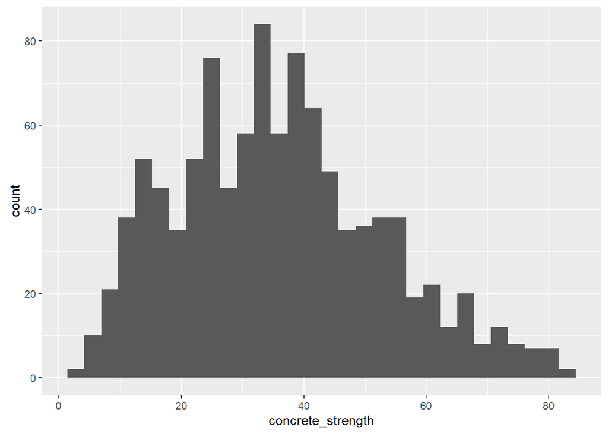

```r
ggplot(concrete, aes(concrete_strength)) +
        geom_histogram()
```

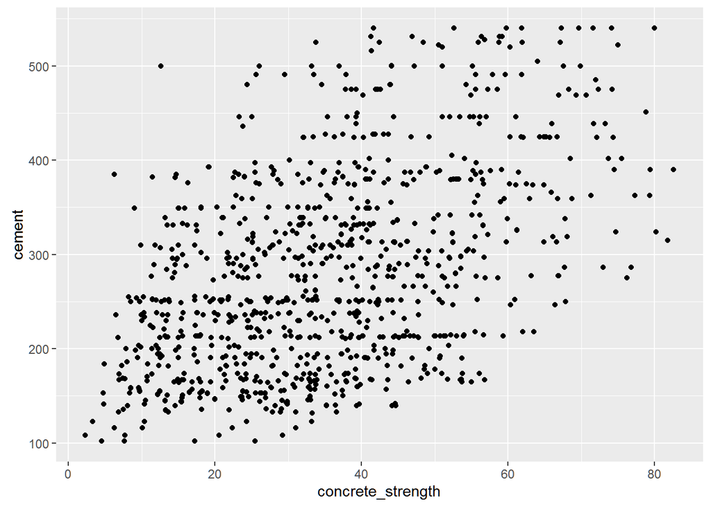

```r
ggplot(concrete, aes(x = concrete_strength, y = cement)) +
        geom_point()
```

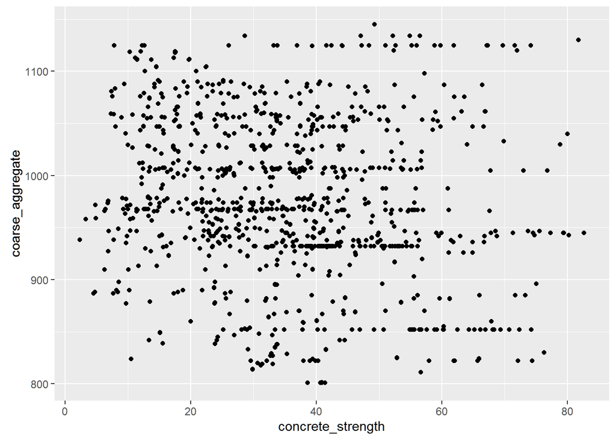

```r
ggplot(concrete, aes(x = concrete_strength, y = coarse_aggregate)) +
        geom_point()
```

Seperate out the outcome from the predictors:

```r
concrete_strength <- concrete$concrete_strength
concrete <- select(concrete, -concrete_strength)
```

Partition the data into a training and a test set

```r
idx <- createDataPartition(concrete_strength, p = 2/3, list = FALSE)

train_set <- concrete[idx, ]
train_outcome <- concrete_strength[idx]

test_set <- concrete[-idx, ]
test_outcome <- concrete_strength[-idx]
```

Fit a single linear model and conduct 10-fold cross-validation to estimate the error:

```r
ctrl <- trainControl(method = "cv")

set.seed(3)
lm_tune <- train(x = train_set, y = train_outcome,
                 method = "lm",
                 trControl = ctrl)

lm_tune
```

```
## Linear Regression
##
## 688 samples
##   8 predictor
##
## No pre-processing
## Resampling: Cross-Validated (10 fold)
## Summary of sample sizes: 620, 618, 620, 619, 619, 620, ...
## Resampling results:
##
##   RMSE      Rsquared
##   10.33395  0.6031678
##
##
```

predict the test set data and save the testset result in a data frame:

```r
test_result <- data.frame(observations = test_outcome, lm_predictions = predict(lm_tune, test_set))
```

Tune the regression tree using “rpart”

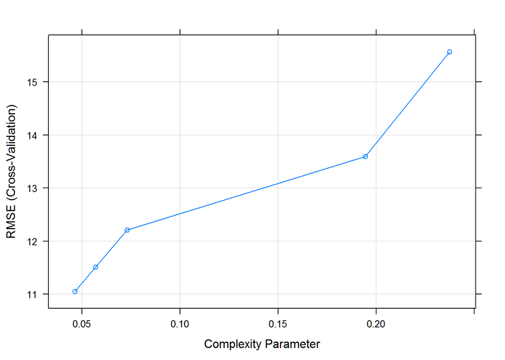

```r
set.seed(3)
tree_tune <- train(x = train_set, y = train_outcome,
                   method = "rpart",
                   trControl = ctrl,
                   tuneLength = 5)
plot(tree_tune)
```

```r
test_result$tree_predictions <- predict(tree_tune, test_set)
```

Plot the regression tree:

[figure not shown]

```r
fancyRpartPlot(tree_tune$finalModel)
```

Fit the multi-addaptive regression model:

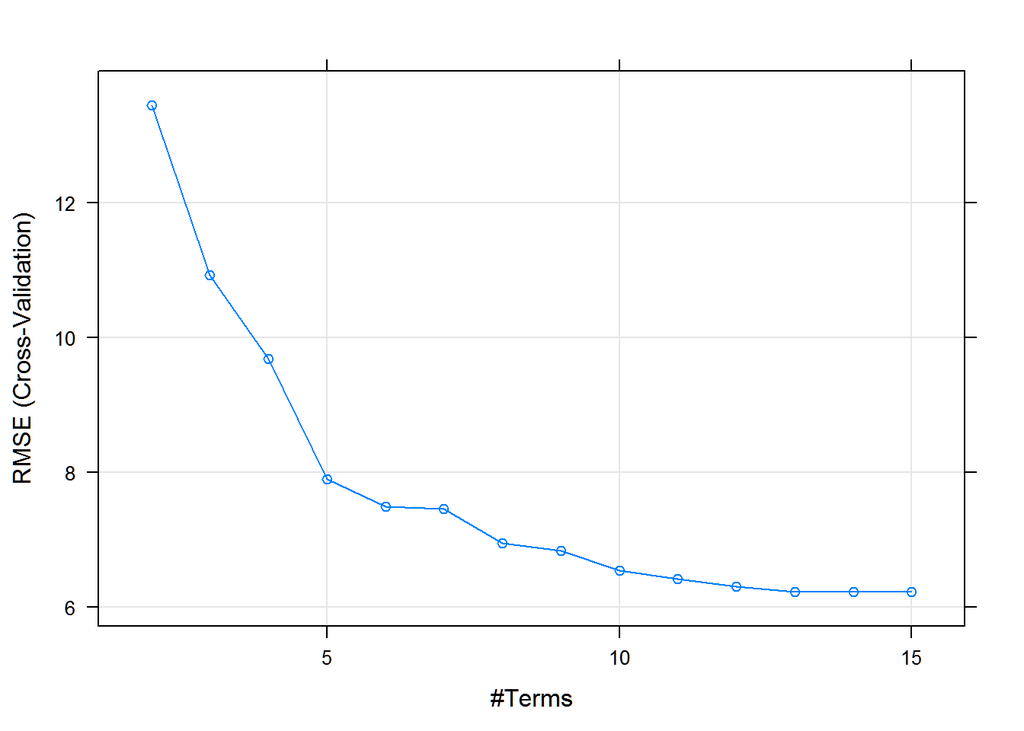

```r
set.seed(3)
mars_tune <- train(x = train_set, y = train_outcome,
                   method = "earth",
                   trControl = ctrl,
                   tuneLength = 20)

plot(mars_tune)
```

```r
test_result$mars_predictions <- predict(mars_tune, test_set)
```

Compute and plot the variable importance

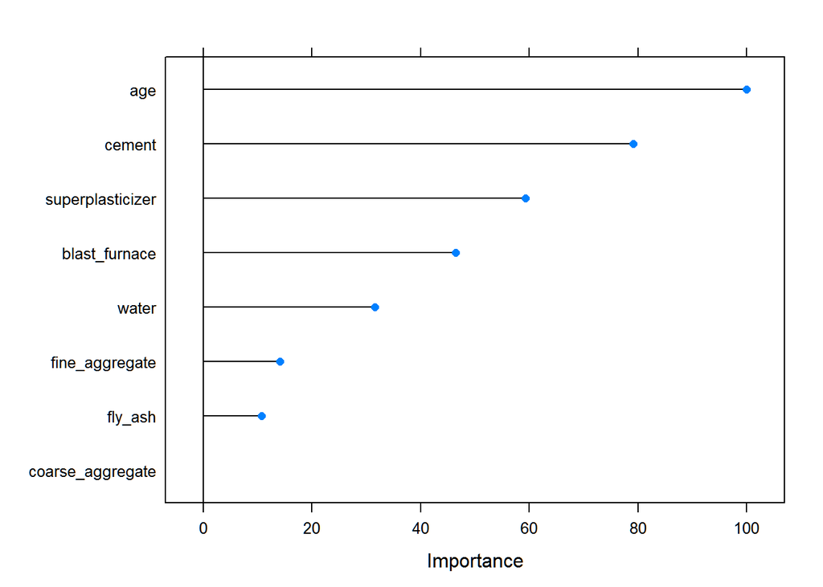

```r
marsImp <- varImp(mars_tune)
plot(marsImp)
```

Support vector machines:

```r
set.seed(3)
svm_tune <- train(x = train_set, y = train_outcome,
                   method = "svmRadial",
                   trControl = ctrl,
                  preProcess = c("center", "scale"),
                  tuneLength = 10)



test_result$svm_predictions <- predict(svm_tune, test_set)
```

```r
head(test_result)
```

```
##   observations lm_predictions tree_predictions        y svm_predictions
## 1     47.02985       26.38179         39.61214 43.73820        47.72030
## 2     36.44777       29.72091         56.38985 35.18530        37.39718
## 3     38.07424       29.82091         39.61214 37.20741        41.21120
## 4     28.02168       23.15487         39.61214 26.83596        26.16310
## 5     42.32693       25.21350         39.61214 40.22184        42.08367
## 6     47.81378       20.29988         39.61214 35.12493        41.88669
```

#### Get test set performance values for each of the models

```r
postResample(pred = test_result$lm_predictions, obs = test_result$observations)
```

```
##       RMSE   Rsquared
## 10.7616358  0.6148596
```

```r
postResample(pred = test_result$tree_predictions, obs = test_result$observations)
```

```
##       RMSE   Rsquared
## 12.1129632  0.5132498
```

```r
postResample(pred = test_result$mars_predictions, obs = test_result$observations)
```

```
##      RMSE  Rsquared
## 6.6853533 0.8512274
```

```r
postResample(pred = test_result$svm_predictions, obs = test_result$observations)
```

```
##      RMSE  Rsquared
## 6.3839084 0.8664826
```